# STAT 1910 Project Proposal

Group L

Last updated on 2024-07-30

```
## Rows: 111
## Columns: 7
## $ Ozone           <int> 41, 36, 12, 18, 23, 19, 8, 16, 11, 14, 18, 14, 34, 6, …
## $ Solar_radiation <int> 190, 118, 149, 313, 299, 99, 19, 256, 290, 274, 65, 33…
## $ Windspeed       <dbl> 7.4, 8.0, 12.6, 11.5, 8.6, 13.8, 20.1, 9.7, 9.2, 10.9,…
## $ Temperature     <int> 67, 72, 74, 62, 65, 59, 61, 69, 66, 68, 58, 64, 66, 57…
## $ Month           <ord> May, May, May, May, May, May, May, May, May, May, May,…
## $ Day             <int> 1, 2, 3, 4, 7, 8, 9, 12, 13, 14, 15, 16, 17, 18, 19, 2…
## $ Season          <chr> "Spring", "Spring", "Spring", "Spring", "Spring", "Spr…
```

[figure not shown]

# 1. Introduction

We often experience drastic ozone changes as temperature changes. This study aims to better understand how temperature affects ozone with respect to Seasons. Ozone occurs both in the Earth’s upper atmosphere and at ground level. Ozone can be good or bad depending on where it is found. Our Ozone here is measured in parts per billion. Our project investigates when these factors such as change in Temperature and Seasons in New York are related to Ozone changes.

To address this question we used an inbuilt R dataset called “air quality” that compiled information on daily air quality measurements from May 1, 1973 to September 30, 1973 in New York. The Source of the inbuilt R dataset is gotten from the New York State Department of Conservation ( ozone data ) and the National Weather Service ( meteorological data ). Each case in our dataset tells us about the air quality of a data in New York within our specified date range.

While doing our exploratory data analysis, we noticed an association between “Temperature” and “Ozone” with respect to “Season” therefore we decided to focus solely on “Ozone” as our outcome variable while our explanatory numerical variable is “Temperature”. We also included a categorical explanatory variable which is “Season”. Our season variable has 3 levels, “spring” ( May ), “Summer” ( June - August ), “Fall” ( September ). Here is a snapshot of 5 randomly chosen rows of the data set we’ll use:

| Ozone | Solar_radiation | Windspeed | Temperature | Month | Day | Season |
| --- | --- | --- | --- | --- | --- | --- |
| 23 | 148 | 8.0 | 82 | Jun | 13 | Summer |
| 29 | 127 | 9.7 | 82 | Jun | 7 | Summer |
| 78 | 197 | 5.1 | 92 | Sep | 2 | Fall |
| 84 | 237 | 6.3 | 96 | Aug | 30 | Summer |
| 59 | 254 | 9.2 | 81 | Jul | 31 | Summer |

# 2. Exploratory data analysis

We had an original sample of 153 rows and 6 variables, however since we had 44 missing values or “NA” with 37 in the Ozone variable and 7 in the Solar_radiation variable because of that we dropped these rows from consideration. Unfortunately, no information was provided as to why some observations had missing values and most did not, so we can not comment on the impact dropping these missing cases has on our results

Our total sample size was 111. The mean of the ozone was greatest for summer season ( n = 58, mean = 54.9, sd = 35.8 ), intermediate for fall ( n = 29, mean = 31.4, sd = 24.1 ) and lowest for spring ( n = 24, mean = 24.1, sd = 22.9 )

The mean Temperature in our specified date range was 77.79 ( sd = 9.53 )

| min | max | mean | sd |
| --- | --- | --- | --- |
| 57 | 97 | 77.79279 | 9.529969 |

Table 1. Summary statistics of Ozone for Spring, Summer, Fall in state of New York from May 1 - September 30, in 1973

| Season | n | mean | median | sd | min | max |
| --- | --- | --- | --- | --- | --- | --- |
| Fall | 29 | 31.44828 | 23.0 | 24.14182 | 7 | 96 |
| Spring | 24 | 24.12500 | 18.0 | 22.88594 | 1 | 115 |
| Summer | 58 | 54.86207 | 48.5 | 35.77338 | 7 | 168 |

Looking at the distribution of Ozone in Figure 1, it does appear to be right skewed and thus we did not apply any transformations. We did notice a potential outlier around an Ozone measurement of 135 and 168, which is something to consider throughout our analysis.

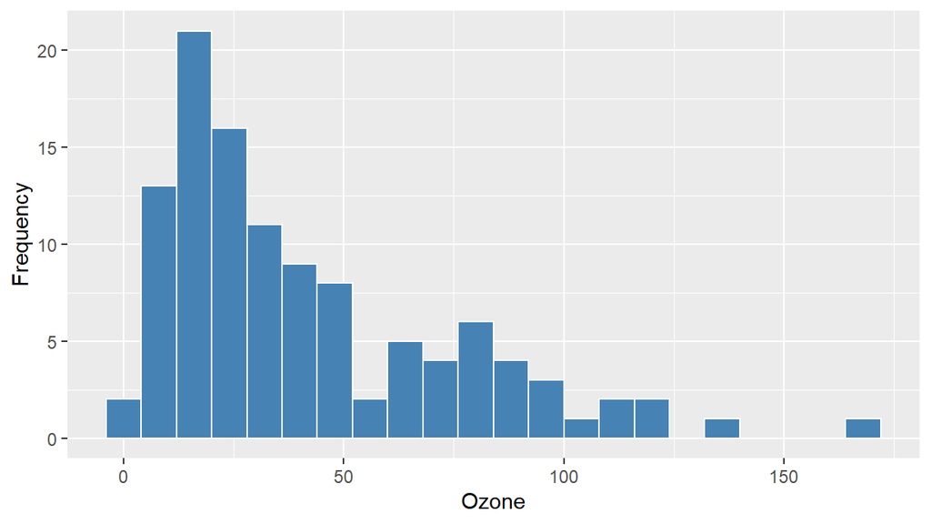

Figure 1. Distribution of Ozone in the State of New York from May - September 1973

In Figure 2, we generated a scatterplot to see the overall relationship between our numerical outcome variable Ozone and our numerical explanatory variable Temperature. As the Temperature increased, there was an associated increase in Ozone. Consistent with this relationship is this is positive correlation coefficient of 0.699.

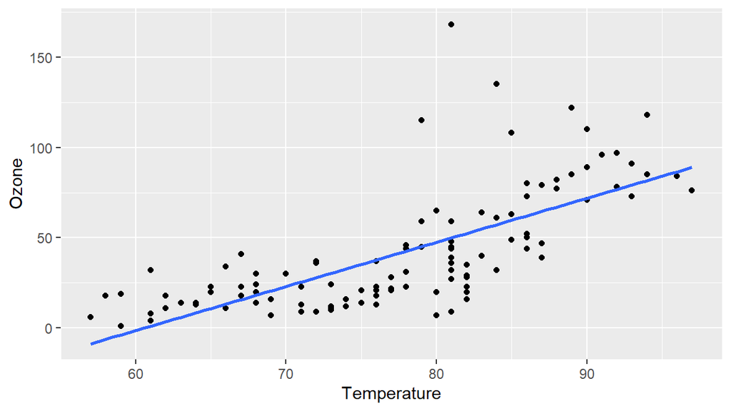

Figure 2. Scatterplot of relationship between Ozone and Temperature in New York from May - Semptember 1973.

Looking at Figure 3, which displays the relationship between our numerical outcome variable Ozone and our categorical explanatory variable Season, the mean Ozone look to be the greatest in Summer, and the lowest in spring, though the difference does not seem to be extreme. Furthemore, there appear to be some potential outliers. In particular, there is a day in summer with a very high mean Ozone. Summer also have the largest variation in Ozone as evidenced by the largest interquartile range.

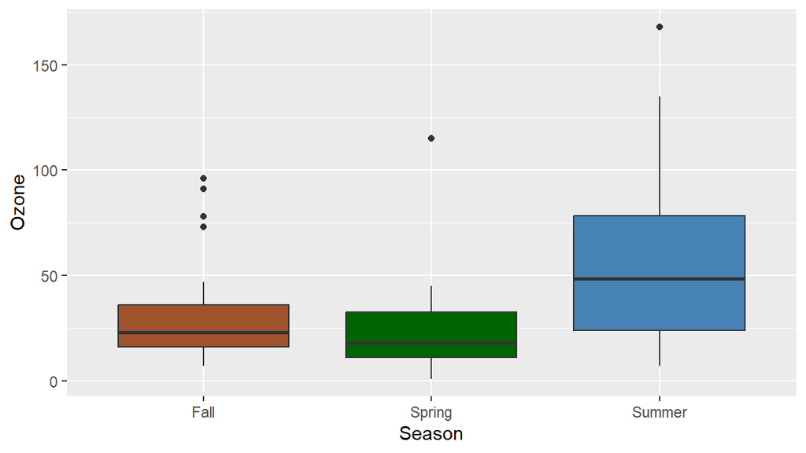

Figure 3. Boxplot of relationship between Ozone and Season category in New York from May - September 1973

Finally, we generated a colored scatterplot displaying the relationship between all three variables at once in Figure 4. While this plot corresponds to an interaction model where we allow for each regression line corresponding to each season to have a different slope, we observe that there appear to be an interaction effect as the 3 slopes do not seem roughly equal .

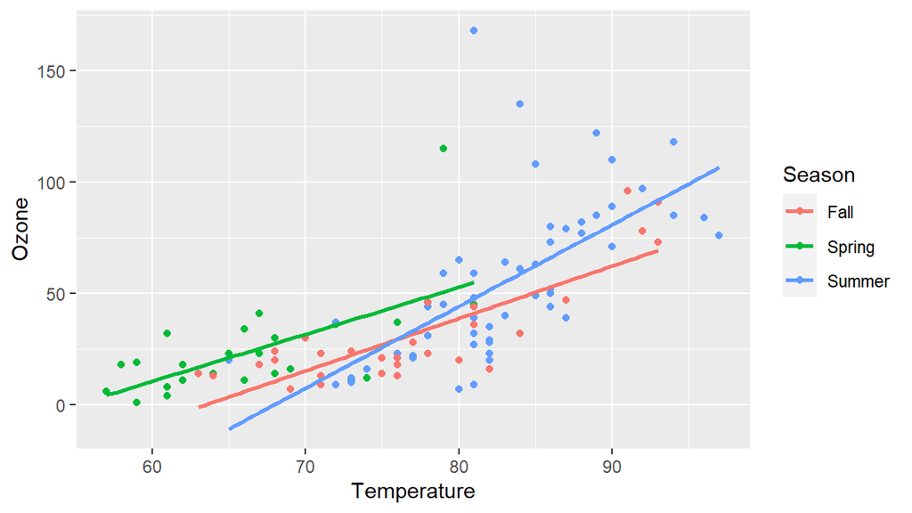

Figure 4. Colored scatterplot of relationship between Ozone and both Temperature and Season in New York from May - September 1973.

# 3. Multiple linear regression

## 3.1 Methods

The components of our multiple linear regression model are the following:

- Outcome variable $y$ = Ozone
- Numerical explanatory variable $x_1$ = Temperature
- Categorical explanatory variable $x_2$ = Season

## 3.2 Model Results

Table 2. Regression table of parallel slopes model of Ozone as a function of Temperature and Season.

| term | estimate | std_error | statistic | p_value | lower_ci | upper_ci |
| --- | --- | --- | --- | --- | --- | --- |
| intercept | -189.764 | 24.639 | -7.702 | 0.000 | -238.607 | -140.921 |
| Temperature | 2.877 | 0.316 | 9.117 | 0.000 | 2.251 | 3.502 |
| Season: Spring | 22.705 | 7.171 | 3.166 | 0.002 | 8.489 | 36.921 |
| Season: Summer | 6.054 | 5.585 | 1.084 | 0.281 | -5.017 | 17.125 |

## 3.3 Interpreting the regression table

The regression equation for Ozone is the following:

$$\begin{aligned}\widehat {score} =& b_{0} + b_{temp} \cdot temp +
b_{spring} \cdot 1_{is\ spring}(x_2) + b_{summer} \cdot 1_{is\
summer}(x_2) \\
=& -189.764 + 2.877 \cdot temp + 22.705 \cdot 1_{is\ spring}(x_2) +
6.054 \cdot 1_{is\ summer}(x_2)
\end{aligned}$$

Thus the three regression lines have equations:

$$\begin{aligned}
\text{Fall Season (in red)}: \widehat {Ozone} =& -189.764 + 2.877
\cdot temp\\
\text{Spring Season (in green)}: \widehat {Ozone} =& -167.059 +
2.877 \cdot temp\\
\text{Summer Season (in blue)}: \widehat {Ozone} =& -183.710 + 2.877
\cdot temp
\end{aligned}$$

## 3.4 Inference for multiple regression

Using the output of our regression table we’ll test two different null hypotheses.The first null hypothesis is that there is no relationship between the Temperature in Fahrenheit and Ozone level (the population slope is zero).

$$\begin{aligned}
\text H_{0} :& \beta_{temp} = 0\\
\text vs\ H_{a} :& \beta_{temp} ≠ 0\\
\end{aligned}$$
There appears to be a positive relationship between the Temperature in Fahrenheit and Ozone Level is 2.877

- The 95% confidence interval for the population slope $β_{temp}$ is (2.25211,3.50189),entirely on the positive side.
- Using a 0.5 significant level,our p-value being 0 provides significant evidence against the null hypothesis $H_{0}$ that $β_{temp}$ = 0,in the favor of the alternative $H_{A}$

The second set of null hypotheses that we are test are that all the differences in intercept for the non-baseline groups are zero.

So it appears the differences in intercept except one are meaningfully different from 0, and hence only one out of three is not roughly equal.

## 3.5 Residual Analysis

We conducted a residual analysis to see if there was any systematic pattern of residuals for the statistical model we ran. Because if there are systematic patterns, then we cannot fully trust our confidence intervals and p-values above.

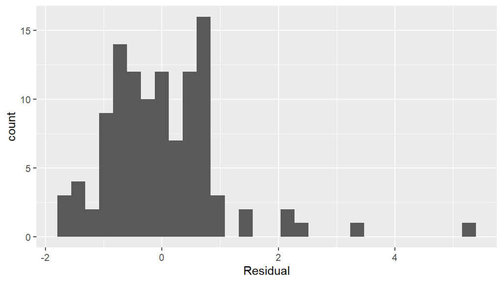

Figure 5. Histogram of residuals for statistical model.

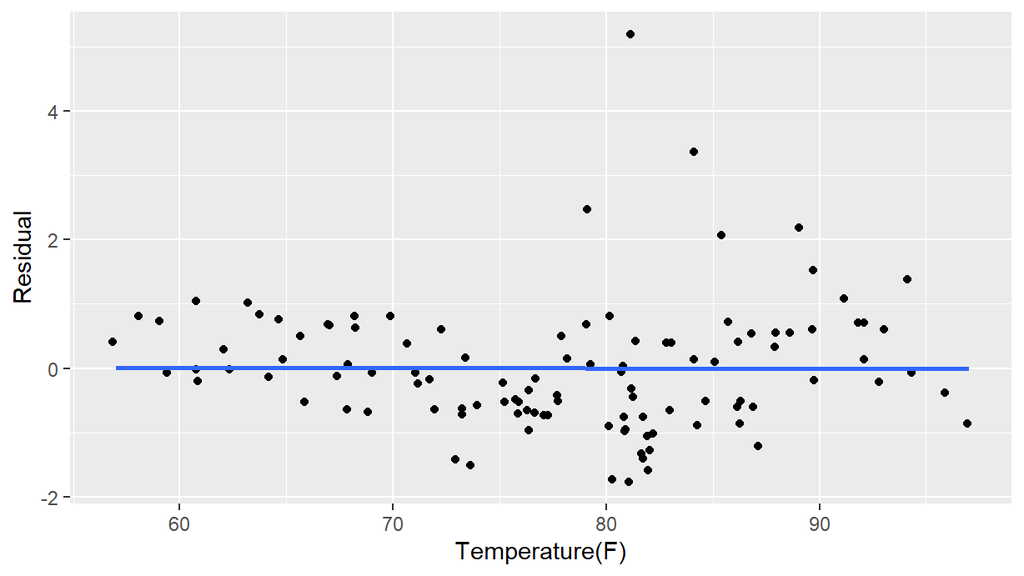

Figure 6. Scatterplots of residuals against the temperature variable.

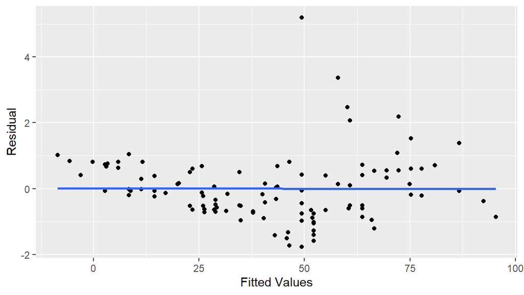

Figure 7. Scatterplots of residuals against the fitted values.

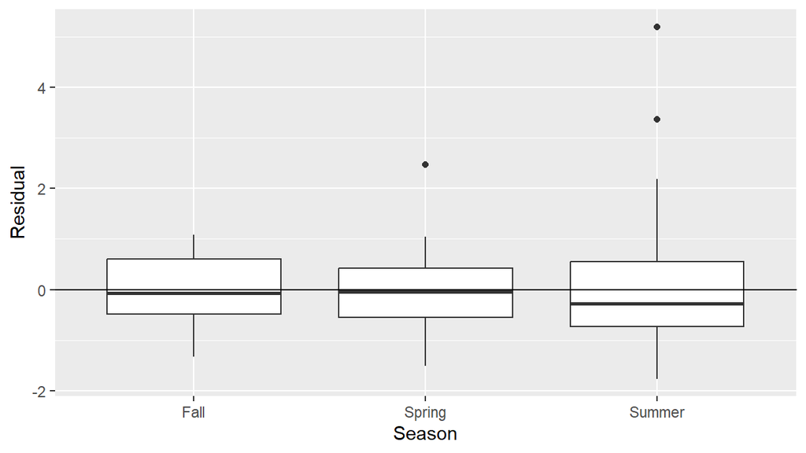

Figure 8. Boxplot of residuals for each Season

# 4. Discussion

## 4.2 Limitations

There were several limitations to this data set. For one, 37 out of the 153 days were missing Ozone data. A close inspection revealed that these were mostly during the summer season in the month of june. Furthermore, these data is only for the state of New York from the months of May-September 1973. As such, our scope of inference is limited to New York during that time span; it may not be appropriate to generalize the results found to the country as a whole.

## 4.3 Further questions

If we were to continue researching this topic, we would like to work with a data set that includes Ozone levels across all states in a full calendar year. This would give us better ideas of Ozone levels across different states. It would also be ideal to use a data set also includes several years worth of data so that we can see if the trends shown persist from year to year. Finally, it would be interesting to incorporate other explanatory variables, particularly ones that policy makers could address through funding programs or laws. The results from this sort of study could be given to the state of New York environmental department so they can make more informed decisions about climate practices prior or during times of drastic ozone level changes. Since our results strongly suggest that Temperature is correlated to Ozone levels, it would be interesting to investigate the temperature distribution across more temperate cities or states and the adverse effects of the ozone level changes.

# 5. Author Statement

## Individual Roles

Facilitator : Yuusuf Adebayo : Made edits and worked on the dataset like the wrangling aspect, ensured everybody participated and submitted the data proposal.

Checker : Okolie Johnviany : Proof-read the code and made slight changes.

Time-Keeper : Abduljalal Ibn Abduljalal : Made sure we worked in line with our created schedule and meeting dates.

Reporter: Daniel Nejo : Made extra findings on a suitable dataset to use and how to improve it.

Recorder : Charles ANonyuo : Took notes of points made during group discussions for future referrals.

## Individual Contribution

*If your group were to earn 5 points on this submission, how should those points be shared across your group members?* Abduljalal Ibn Abduljalal gets 0.8 point, Okolie Johnviany gets 1.0 point, Yuusuf Adebayo gets 1.2 points, Daniel Nejo gets 0.8 point, Anonyuo Charles gets 1.2 points.

# 6. Citations and References

1.Donald,Wuebbles.Ozone depletion(atmospheric phenomenon).Britannica,November 2023. https://www.britannica.com/science/ozone-depletion

2.United States Environmental Protection Agency.Ground-level Ozone Basics.June 2023. https://www.epa.gov/ground-level-ozone-pollution/ground-level-ozone-basics

3.The Havard Gazette.”The complex relationship between heat and ozone”.April 2016. https://news.harvard.edu/gazette/story/2016/04/the-complex-relationship-between-heat-and-ozone/